# Crimes in Chicago - A Predictive Approach

# Interpretation on Graph 5

# Graph 6(a) - Top 10 most dangerous communities from 2001 - present

```r
areadata <- data2[which(data2$Community.Area!= ""),]
areaMissRatio <- 1 - nrow(areadata)/nrow(nacrimedf)
areaMissRatio
```

```
## [1] -0.01168498
```

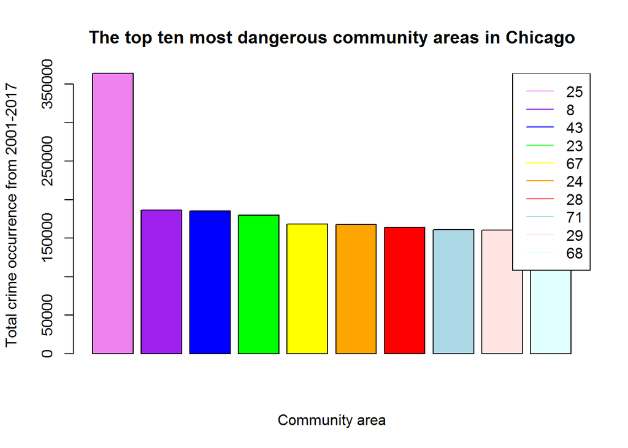

```r
aggdata_area <- aggregate(quantity~Year+Community.Area,data=areadata,FUN=sum)
aggdata_area2 <- aggregate(quantity~Community.Area,data=aggdata_area,FUN=sum)
aggdata_area2 <- aggdata_area2[order(aggdata_area2$quantity,decreasing=TRUE),]
top10_area <- aggdata_area2[1:10,]
with(top10_area,barplot(top10_area$quantity,col=c("violet","purple","blue","green","yellow","orange","red","lightblue","mistyrose","lightcyan"),main="The top ten most dangerous community areas in Chicago", xlab="Community area",ylab="Total crime occurrence from 2001-2017"))
legend("topright",lty="solid",col=c("violet","purple","blue","green","yellow","orange","red","lightblue","mistyrose","lightcyan"),legend=top10_area$Community.Area)
```

```r
top10_area <- aggdata_area2[1:10,]
top10_area
```

```
##    Community.Area quantity
## 26             25   364071
## 9               8   186621
## 44             43   184964
## 24             23   179985
## 68             67   168269
## 25             24   167959
## 29             28   164312
## 72             71   160800
## 30             29   160468
## 69             68   153292
```

# Graph 6(b) - Trend for top 5 most dangerous communities based on crimes.

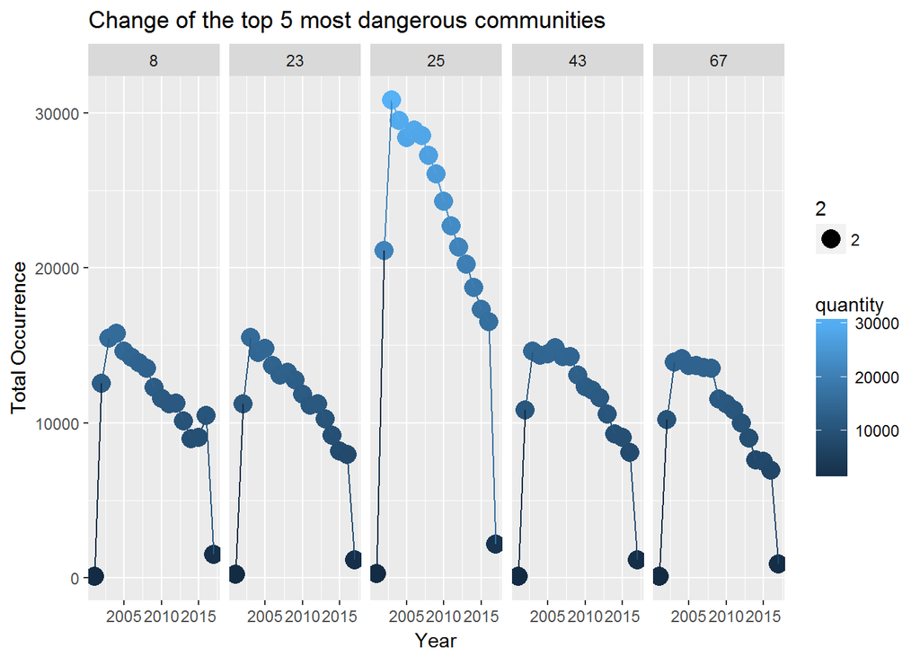

```r
top3_area <- aggdata_area2[1:5,]
subaggdata_area2 <- aggdata_area[which(aggdata_area$Community.Area %in% top3_area$Community.Area),]
ggplot(data=subaggdata_area2,aes(x=Year,y=quantity)) + facet_grid(.~Community.Area) + geom_point(aes(size=2,col=quantity)) + geom_line(aes(group=1, col=quantity)) + ggtitle("Change of the top 5 most dangerous communities") + xlab("Year") + ylab("Total Occurrence")
```

# Interpretation of Graph 6 - 6a and 6b

Graph 6(A) represents the top ten most dangerous community areas in Chicago based on the crime occurrence from 2001-2017. This gives the user a brief overview of what community needs more attention. Graph 6(B) is a more drilled version of graph 6(A), where the trend for the graph 6(A) is shown over time. This trend can be helpful for the lawmakers and the law enforcement agents in predecting the crimes and securing the commumity areas that need more attention.

# Graph 7 Heat map, representing the crimes by the time of the day.

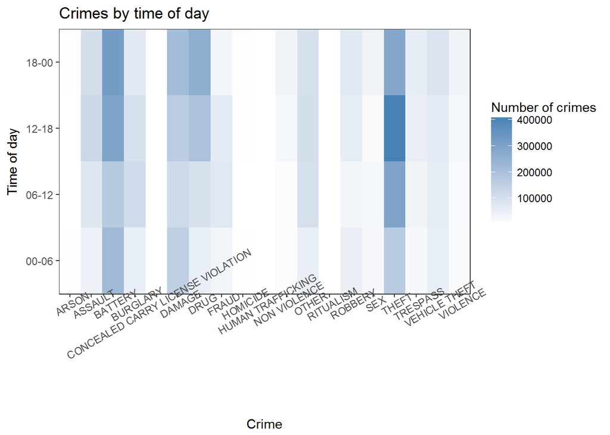

```r
library(dplyr)

temp <- aggregate(crime.data$crime, by = list(crime.data$crime,crime.data$time.tag), FUN = length)
names(temp) <- c("crime", "time.tag", "count")


ggplot(temp, aes(x = crime, y = factor(time.tag))) +
  geom_tile(aes(fill = count)) +
  scale_x_discrete("Crime", expand  = c(0,0)) +
  scale_y_discrete("Time of day", expand  = c(0,-2))  +
  scale_fill_gradient("Number of crimes", low=  "white", high  = "steelblue")+
  theme_bw() + ggtitle("Crimes by time of day") +
  theme(panel.grid.major  = element_line(colour  = NA), panel.grid.minor  = element_line (colour  = NA))+
  theme(axis.text.x = element_text(angle = 30))
```

# Interpretation of graph 7

The heat map of the crimes based on the time of the day represents the number of crimes. The higher variant of the steelblue color represnts more number of crimes for that specific time domain. So, it can be interpreted that the crime category “theft” occurs more frequently during the time domain 12 - 18. In the subsequent graphs we will try to integrate the community area (i.e. the exact location from the dataset).

# Graph 8

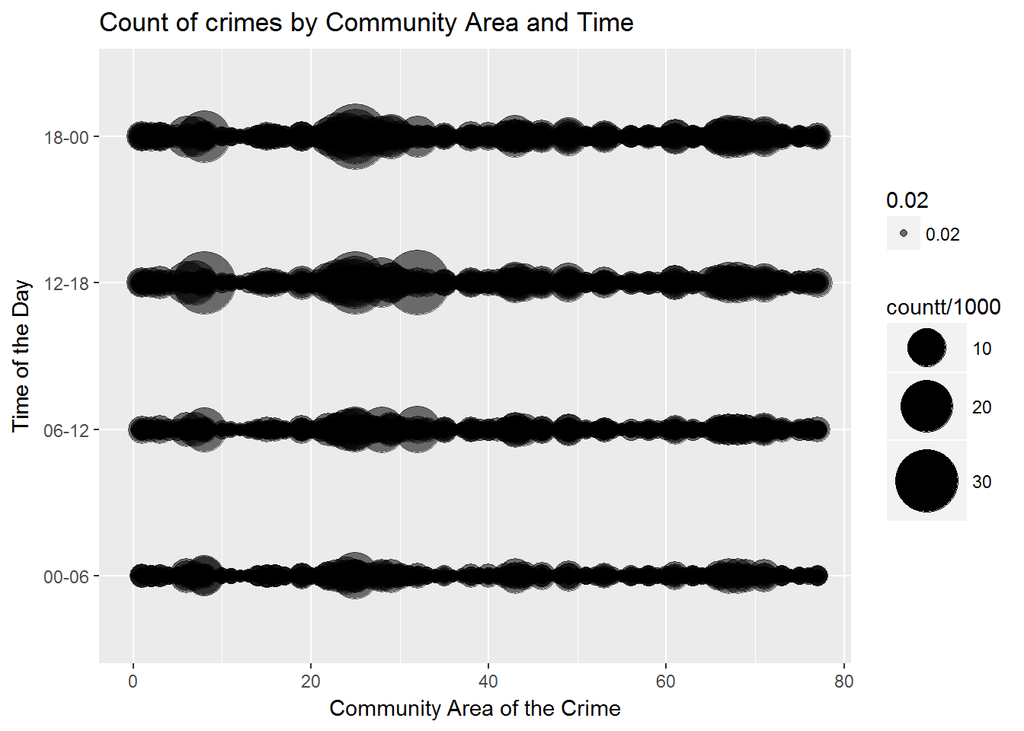

```r
library(dplyr)
df5$Date <- NULL
Crime_Location <- df5 %>% group_by(Community.Area,crime,time.tag) %>% dplyr::summarise(countt = n())
Crime_Location<-Crime_Location[order(-Crime_Location$countt),]

ggplot(Crime_Location, aes(x = Community.Area, y = time.tag)) +
    geom_point(aes(size = countt/1000, alpha=.02)) +
    scale_size(range = c(1,15)) + ggtitle ("Count of crimes by Community Area and Time")+labs(x="Community Area of the Crime", y ="Time of the Day")
```

# Interpretation of graph 8

The above graph represents the occurance of crime based on the time interval and the community area (i.e. location). We can further improvise the visualization by adding the type of crime along with the factors considered in the above graph.

# Graph 9 Bubble graph for visualization of the factors : Place, Time, Rate (# of crimes) and Type of Crimes.

```r
library(dplyr)
df5$Date <- NULL
Crime_Location <- df5 %>% group_by(Community.Area,crime,time.tag) %>% dplyr::summarise(countt = n())
Crime_Location<-Crime_Location[order(-Crime_Location$countt),]



Crime_Location
```

```
## Source: local data frame [5,026 x 4]
## Groups: Community.Area, crime [1,305]
##
##    Community.Area   crime time.tag countt
##             <int>   <chr>    <chr>  <int>
## 1              25    DRUG    18-00  33778
## 2              32   THEFT    12-18  32905
## 3              25    DRUG    12-18  30322
## 4               8   THEFT    12-18  29965
## 5              25 BATTERY    18-00  22597
## 6              25 BATTERY    12-18  20872
## 7               8   THEFT    18-00  19971
## 8              28   THEFT    12-18  18295
## 9              23    DRUG    18-00  16505
## 10             24   THEFT    12-18  16410
## # ... with 5,016 more rows
```

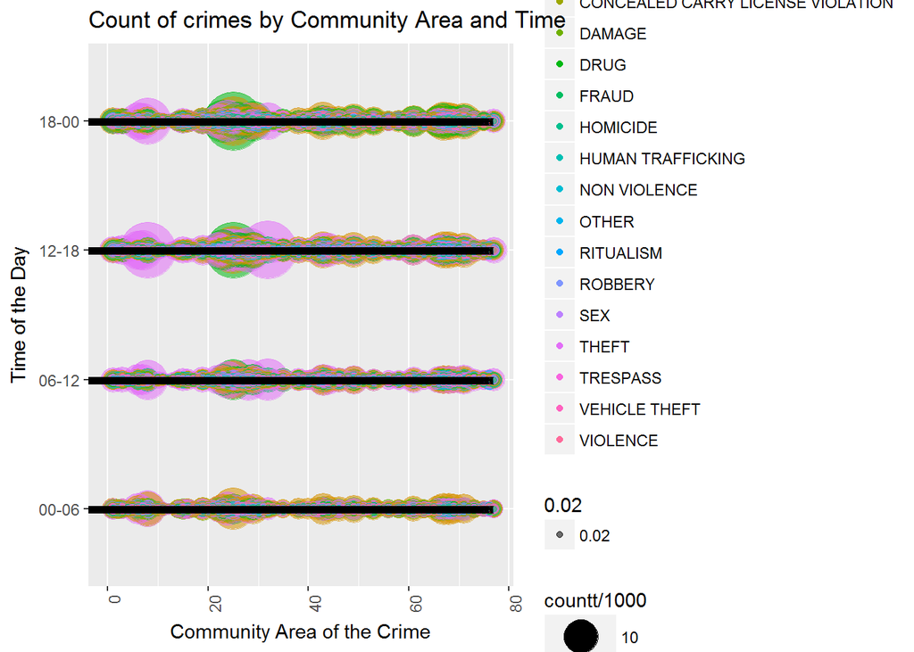

```r
ggplot(Crime_Location, aes(x = Community.Area, y = time.tag, label = crime)) +
    geom_point(aes(size = countt/1000, colour = crime, alpha=.02)) +
    geom_text(hjust = 1, size = 2) +
    scale_size(range = c(1,15)) +
    theme(axis.text.x=element_text(angle=90,hjust=1.0,vjust=1.0)) + ggtitle ("Count of crimes by Community Area and Time")+labs(x="Community Area of the Crime", y ="Time of the Day")
```

# Interpretation of graph 9

The above graph, represents the types of crime, the rate of crime(i.e. # of crimes), the time interval and the community area. For the descision makers this graph serves as an important factor. The graph shows significant intensity of the crimes between the interval of the communities from 20 to 30. Our previous graphs 6(A) and 6(B) indicates that the community that suffers maximum crime is the community area 25. On further analytics, the time intervals and the types of crime play an important role.

# Summary

In the first level of analysis, we tried to understand the overall trend of the Crimes in Chicago since 2001- Present under various factors. The first three graphs we analyze the increase and decrease of the number of crimes based on the Community Area and the type of crimes and the time of the day. By understanding these trends we try to drill down the data and focus on the comparison of the number of crimes based on the type of crime, community area and the time of the day. Reason for choosing Community Area

The City of Chicago is divided into different community areas which gives us a better understanding of which part of the city has more crime rates.

Reason for choosing Types of Crimes

The types of crimes give us a better understanding to analyze the different types of crimes that have been committed in the past in the City of Chicago.

Reason for choosing Time of the Day  
On analyzing the time of the day, we could drill deep into the particular time of the day a crime has been committed.

# STORY!!

This dataset reflects reported incidents of crime (with the exception of murders where data exists for each victim) that occurred in the City of Chicago from 2001 to Present.

The Crime category includes: 1. Arson 2. Criminal Sexual Assault 3. Criminal Trespassing 4. Deceptive Practice 5. Domestic Violence 6. Gambling 7. Homicide 8. Interfere with Public Officer 9. Intimidation 10. Kidnapping 11. Liquor Law Violation 12. Obsenity 13. Offences involving Children 14. Other Narcotic Violation 15. Prostitution 16. Public Indecency 17. Public Peach Violation 18. Ritualism 19. Sex Offence 20. Stalking 21. Weapons Violation The crime data provides us the information about the type of crime happened at any time at various locality, also, the time of crime. With the given crime data set, we cleansed based on the requirement. Various, similar, crime type have been considered under the same categories.

Based on the data that has been considered we would propose to predict the crime, most likely, to be happened at any particular locality and at the time of the day.